# Survival curves

Peter Ralph

5 January 2021 – Advanced Biological Statistics

# Overview

## “Survival” analysis:

We are interested in *how long until* some particular thing happens, and *how this depends* on some covariates.

*Example:* how years until death depends on cancer grade at diagnosis and drug treatment.

*Example:* how day of first budburst depends on species and local temperature.

## Surivival data

*Ex:* For each patient, date of diagnosis and cancer grade; date of death or last follow-up.

*Ex:* For each plant, species, date of first budburst or last survey.

Both examples are **right censored**: for some subjects, we don’t know how the actual time, only a lower bound on it.

**Key assumption:** any censoring is *noninformative*,

i.e., our data collection does not depend on the status of the subjects.

Example of *informative* censoring: patient dropout due to worsening symptoms.

## What do we want to know?

The *survival curve:*

$$\begin{aligned}
S(t)
&=
\P\{\text{still 'alive' after $t$ time units}\} ,
\end{aligned}$$

*Note:* this is always *decreasing*.

and the *hazard rate:*

$$\begin{aligned}
h(t)
&=
\text{(mean number of 'deaths' per still-alive subject,}
\\ &\qquad \text{per unit time at $t$)} ,
\end{aligned}$$

which is

$$\begin{aligned}
h(t) = - \frac{d}{dt} \log S(t) .
\end{aligned}$$

The *hazard rate*,

the rate the event of interest happens at,

is the slope of the survival curve on a log scale.

## Nonparametric versus parametric?

We’ll look at some methods across the nonparametric-to-parametric continuum.

- *Nonparametric:* fewer assumptions.
- *Parametric:* fits a full, generative probability model.

Replacing “death” with “your next donut”, which of these curves would you rather describe the distribution of time until your next donut?

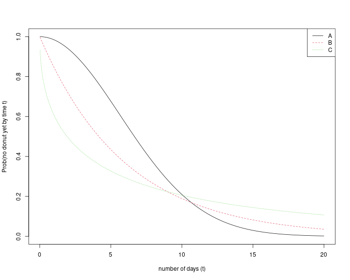

## More information:

- A [series](https://www.ncbi.nlm.nih.gov/pmc/articles/PMC2394262/) [of](https://www.ncbi.nlm.nih.gov/pmc/articles/PMC2394368/) [nice](https://www.ncbi.nlm.nih.gov/pmc/articles/PMC2376927/) [reviews](https://www.ncbi.nlm.nih.gov/pmc/articles/PMC2394469/), by Clark, Bradburn, Love, and Altman.
- A [tutorial](https://www.emilyzabor.com/tutorials/survival_analysis_in_r_tutorial.html) by Emily Zabor.

[figure not shown]

the [CRAN task view](https://cran.r-project.org/web/views/Survival.html)

# Datasets:

## [NCCTG Lung Cancer Data](https://www.ncbi.nlm.nih.gov/pubmed/8120560)

```r
library(survival)
data(lung)
## help(lung)
```

```
NCCTG Lung Cancer Data

Description:

     Survival in patients with advanced lung cancer from the North
     Central Cancer Treatment Group.  Performance scores rate how well
     the patient can perform usual daily activities.

Usage:

     lung
     cancer

Format:

       inst:       Institution code
       time:       Survival time in days
       status:     censoring status 1=censored, 2=dead
       age:        Age in years
       sex:        Male=1 Female=2
       ph.ecog:    ECOG performance score as rated by the physician.
                   0=asymptomatic, 1= symptomatic but completely ambulatory, 2= in bed
                   <50% of the day, 3= in bed > 50% of the day but not bedbound, 4 =
                   bedbound
       ph.karno:   Karnofsky performance score (bad=0-good=100) rated by physician
       pat.karno:  Karnofsky performance score as rated by patient
       meal.cal:   Calories consumed at meals
       wt.loss:    Weight loss in last six months

Note:

     The use of 1/2 for alive/dead instead of the usual 0/1 is a
     historical footnote.  For data contained on punch cards, IBM 360
     Fortran treated blank as a zero, which led to a policy within the
     section of Biostatistics to never use "0" as a data value since
     one could not distinguish it from a missing value.  The policy
     became a habit, as is often the case; and the 1/2 coding endured
     long beyond the demise of punch cards and Fortran.

Source:

     Terry Therneau

References:

     Loprinzi CL. Laurie JA. Wieand HS. Krook JE. Novotny PJ.  Kugler
     JW. Bartel J. Law M. Bateman M. Klatt NE. et al.  Prospective
     evaluation of prognostic variables from patient-completed
     questionnaires. North Central Cancer Treatment Group.  Journal of
     Clinical Oncology. 12(3):601-7, 1994.
```

## Simulation: Constant hazard rate

Time until arrival of a high-energy neutrino in each of many detectors:

```r
nrate <- 1 / 365
study_time <- 4 * 365
nobs <- 228
neutrinos <- data.frame(
        detector_id = 1:nobs,
        time = rexp(nobs, rate=nrate))
neutrinos$status <- (neutrinos$time < study_time)
neutrinos$time <- pmin(study_time, neutrinos$time)
head(neutrinos)
```

```
##   detector_id      time status
## 1           1  72.39294   TRUE
## 2           2 241.22677   TRUE
## 3           3 103.47423   TRUE
## 4           4  13.94004   TRUE
## 5           5 172.70947   TRUE
## 6           6 534.22391   TRUE
```

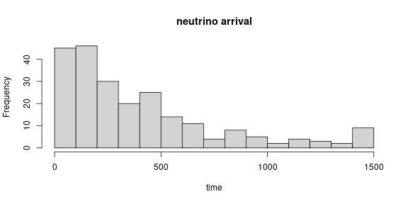

## Simulation: Increasing hazard rate

Time until failure of lightbulbs, that wear out as time goes on:

```r
lmean <- 2 * 365
bulbs <- data.frame(
        bulb_id = 1:nobs,
        time = abs(rnorm(nobs, sd=lmean)))
bulbs$status <- (bulbs$time < study_time)
bulbs$time <- pmin(study_time, bulbs$time)
head(bulbs)
```

```
##   bulb_id      time status
## 1       1  511.5466   TRUE
## 2       2  404.5635   TRUE
## 3       3  610.5038   TRUE
## 4       4 1164.0494   TRUE
## 5       5  149.6198   TRUE
## 6       6  251.9142   TRUE
```

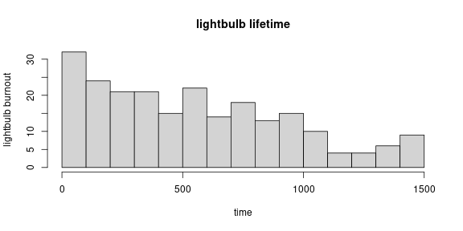

# Kaplan-Meier curves

## Estimating probabilities

Suppose that:

- we start with 100 chickens
- in the first year, 25 of them die
- in the second year, 25 of them die
- at the end of the second year, we give 25 of the survivors away
- in the third year, 15 of them die

**Questions:**

- What percent survived each year? (of those that began that year alive)
- Find the probability of surviving for 1, 2, and 3 years,
- and draw the survival curve.

The **Kaplan-Meier survival curve** is a purely empirical, nonparametric estimate of survival probability:

- one interval per unique event time
- estimated probability of surviving an interval is the proportion that did
- and so the probability of surviving until $t$ is the product of all the survival probabilities before $t$

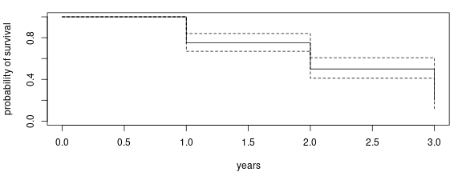

```r
plot(Surv(time=rep(1:3, times=c(25, 50, 25)),
          event=c(rep(2, 25), rep(2, 25), rep(1, 25), rep(2, 15), rep(1, 10))), xlab="years", ylab="probability of survival", ylim=c(0,1))
```

## Neutrinos:

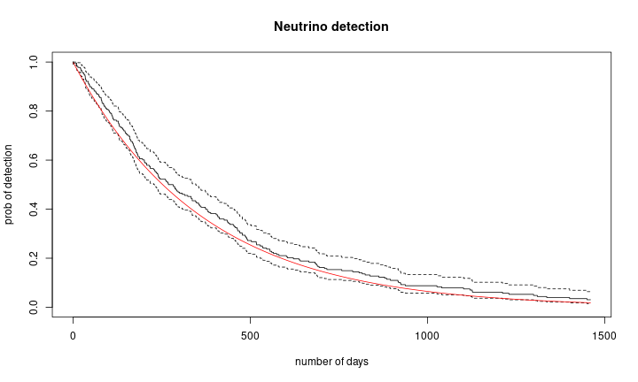

```r
neutrino_sf <- survfit(Surv(time, status) ~ 1, data=neutrinos)
plot(neutrino_sf, xlab='number of days', ylab='prob of detection', main="Neutrino detection")
lines(1:study_time, pexp(1:study_time, rate=nrate, lower.tail=FALSE), col='red')
```

## Light bulbs:

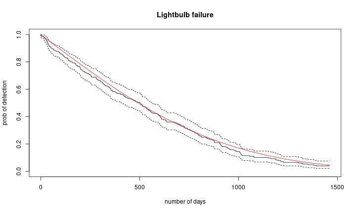

```r
bulb_sf <- survfit(Surv(time, status) ~ 1, data=bulbs)
plot(bulb_sf, xlab='number of days', ylab='prob of detection', main="Lightbulb failure")
lines(1:study_time, 2 * pnorm(1:study_time, sd=lmean, lower.tail=FALSE), col='red')
```

## Hazard rate is slope of survival on a log scale:

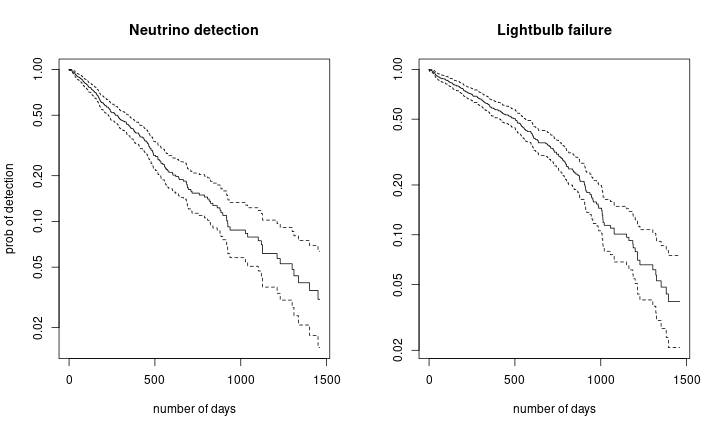

```r
layout(t(1:2))
plot(neutrino_sf, xlab='number of days', ylab='prob of detection', main="Neutrino detection", log='y')
plot(bulb_sf, xlab='number of days', main="Lightbulb failure", log='y')
```

## Lung cancer survival:

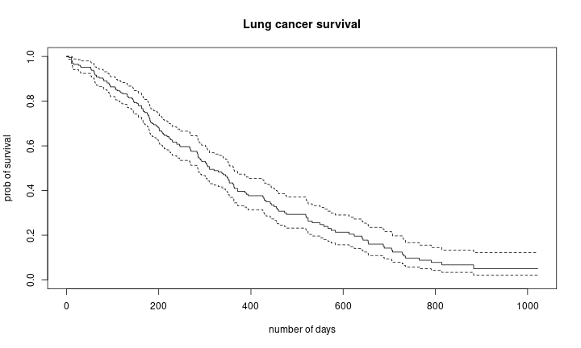

```r
lung_sf <- survfit(Surv(time, status) ~ 1, data=lung)
plot(lung_sf, conf.int=TRUE, xlab='number of days', ylab='prob of survival', main="Lung cancer survival")
```

## Hazard rate is slope of survival on a log scale:

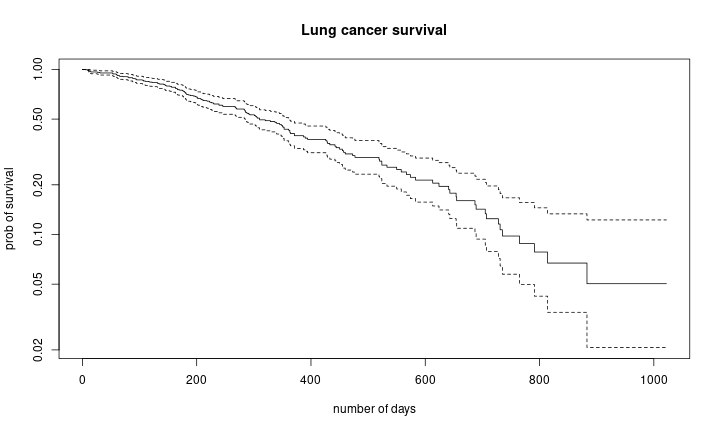

## Survival, by sex:

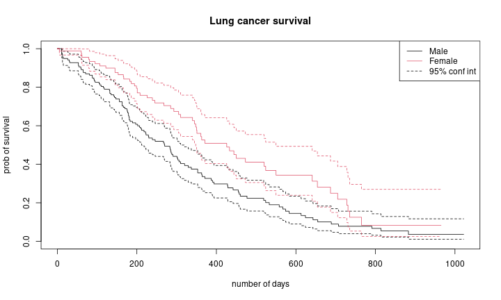

```r
lung_sf_bysex <- survfit(Surv(time, status) ~ sex, data=lung)
plot(lung_sf_bysex, col=1:2, conf.int=TRUE, xlab='number of days', ylab='prob of survival', main="Lung cancer survival")
legend("topright", lty=c(1,1,2), col=c(1,2,1), legend=c("Male", "Female", "95% conf int"))
```

# Interpretation interlude:

## Interpret this:

- What is the “number at risk”?
- The blue curve hits 50% at 20 days. What does that mean?
- “Patients treated with anticoagulation were generally sicker” - so, what do we conclude?

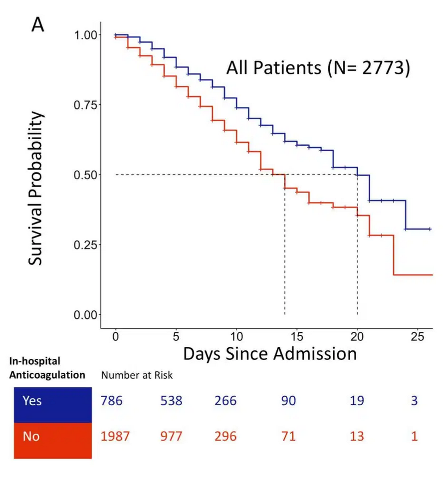

Survival curves

From [Paranjpe et al](https://www.sciencedirect.com/science/article/abs/pii/S0735109720352189) via emcrit.org/pulmcrit/sinai